# Requiring tools to deconstruct items

Anyone can dig up a bit of soil and pick up some twigs off the ground, or scoop up a rock. But when faced with a boulder or an entire tree, you can’t take those down with your bare hands.

In this lesson, we’ll add a way to require tools like axes and pickaxes to deconstruct certain entities like boulders and trees.

## Creating tools

We can start this off by creating some tools so we have items to work with. Let’s start with an axe.

Create a new scene with a `BlueprintEntity` named *AxeBlueprint* as the root node. Add a `Sprite` node as a child of it and and assign it the `blueprints.svg` texture.

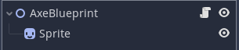

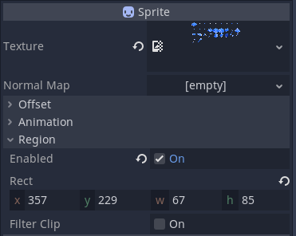

Set its region to be the pristine metal axe by turning on *Region -> Enabled* and selecting the right slice in the *TextureRegion* bottom panel.

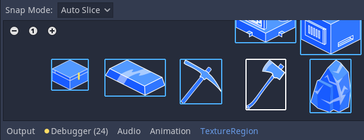

To make it a tool and be able to recognize it in code, we can add a separate script that extends the functionality we already have on blueprints.

Assign a new script, `ToolEntity.gd`, to the *AxeBlueprint*. You can save it in the `res://Entities/Blueprints/` directory.

We’ll re-use this script for every tool.

```
class_name ToolEntity
extends BlueprintEntity

# This property is a multiplier for the deconstruct. With it, bad tools can be
# slower, and high-quality tools can work faster.
# `1.0` is the default speed.
export var tool_speed := 1.0

# The category the tool belongs to, like "Axe" or "Pickaxe". This lets us
# identify what kind of tool this is.
# For example, an axe can cut trees but not break boulders.
export var tool_name := ""
```

With the script assigned, you can configure the `AxeBlueprint.tscn` scene as an unplaceable tool with the “Axe” tool name and a tool speed of 1.

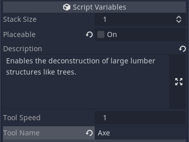

If you go back to the main `Simulation.tscn` scene and use the `GUI`’s node debug dictionary to give yourself an axe, upon playing the game, you may notice something odd with the sprite.

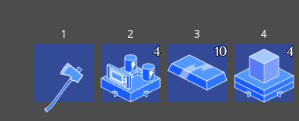

Because we are using auto-slice in the *TextureRegion* tool panel, we do not have an exact 100x100 pixel sprite, and that changes what counts as its center.

Like we did with the Stirling engine and battery, we have to offset it by `25` or so pixels to make up the difference.

## Extra tools

You can now repeat the process to create a pickaxe tool for stone and ore.

To do this efficiently, you can duplicate the `AxeBlueprint.tscn` file and edit the new copy. Be sure to name the root node *PickaxeBlueprint* and to set its *Tool Name* property to “Pickaxe.”

In the final demo, I repeated the process to create a “Crude Axe” and a “Crude Pickaxe”.

They still use the “Axe” and “Pickaxe” values for the *Tool Name* property, but the player creates them with stone instead of metal. They should be less efficient: I set with `0.1` for their *Tool Speed* property.

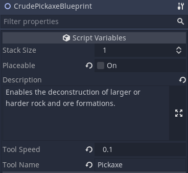

If you do the same, you should end up with an `AxeBlueprint.tscn`, `PickaxeBlueprint.tscn`, `CrudeAxeBlueprint.tscn`, and `CrudePickaxeBlueprint.tscn`.

You can see the sprites for the “crude” versions of the tools on the left in the image below.

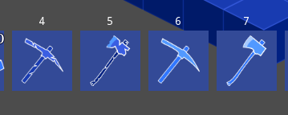

## Creating something to break with tools

While we’re making entities, we should create an object that requires a tool to mine.

We’ll go with the boulder. Like the rocks we made in the previous chapter, it will drop stone, except it will drop more than one.

You will never hold a boulder in your inventory, so we don’t have to create a blueprint for it.

We create a new scene with a `StaticBody2D` named *BoulderEntity* at its root node. It should have a `Sprite` and, for collision, a `CollisionPolygon2D`.

[figure not shown]

The sprite has its texture assigned to the `tileset.svg` texture with its regions data set to one of the boulders.

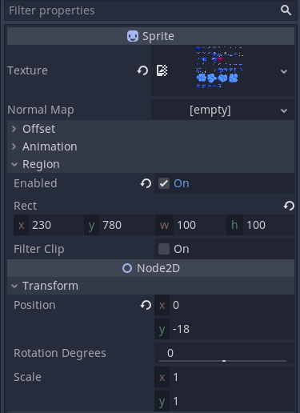

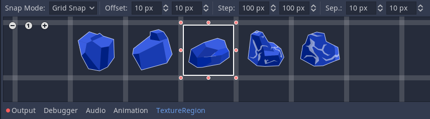

With the sprite displayed on the screen, we can use it as a reference to build an appropriate polygon on the `CollisionPolygon2D` node.

Notice how I moved the sprite up a bit below to align its base with the scene’s origin.

You’ll have to test it in-game to see how it feels when the player walks around it.

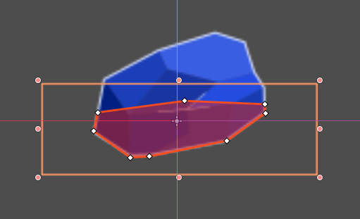

Note that you can edit a collision shape while the game is running; it will update live. To do so, ensure you have *Debug -> Synchronize Scene Changes* and *Debug -> Visible Collision Shapes* turned on.

Like with rocks and twigs, we have more than one possible sprite, so we can use a script to pick one at random when the boulder is first created. Add a new script, `BoulderEntity.gd`, to the root node. It should extend `Entity` as a class.

```
extends Entity

## These are the three regions in `tileset.svg` for the boulder sprites.
const REGIONS := [
    Rect2(10, 780, 100, 100),
    Rect2(120, 780, 100, 100),
    Rect2(230, 780, 100, 100)
]


func _ready() -> void:
    ## We set the sprite region to a random region.
    var index := int(rand_range(0, REGIONS.size() - 1))
    $Sprite.region_rect = REGIONS[index]
```

We have an issue in that the boulders’ sprites don’t have the same shape for where they meet the ground.

We can create three collision polygon nodes and disable the ones we’re not using.

Create two more `CollisionPolygon2D` nodes and for each, change the `Sprite`‘s’ region to one of the two remaining boulders and draw a collision polygon for that boulder.

Make sure that the order they appear in the scene tree is in the same as they are in the `REGIONS` array. That is, from the leftmost to the rightmost sprite.

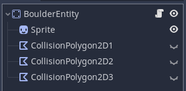

Hide them and set their *Disabled* property to `true` so those we keep hidden don’t interfere with collisions.

Then head back to `_ready()`, and we can finish the function and enable the right collision polygon.

```
func _ready() -> void:
    #...
    ## Enable the appropriate collision polygon. Sprite is child 0,
    ## so `index` + 1 should be the correct child.
    var collision: CollisionPolygon2D = get_child(index + 1)
    collision.disabled = false
    collision.show()

    ## We randomly flip the entire boulder on the X axis for more visual variety.
    scale.x = 1 if rand_range(0, 10) < 5 else -1
```

At the moment, with the way we have our Library set up, if we deconstructed this boulder, it would try to spawn a boulder entity.

Not only does it not exist, but we also don’t want it to spawn a boulder: we want it to drop a bunch of stone. But we already covered that eventuality.

In our `Library.gd` autoload, we already check if the entity has a special `get_entity_name()` function. So when the deconstruct code executes, we can tell it the name is “Stone” so it drops stone instead of boulders.

```
## Tells the Library what name it should pretend to wear instead of its scene name.
func get_entity_name() -> String:
    return "Stone"
```

That means it will display the name of the entity as “Stone” when hovered over with the mouse because of how we have our information label set up.

If you’d like to separate the two, I leave it as an exercise to you, dear reader.

To specify the number of stones to drop, you can override the `_get_pickup_count()` getter. I went with `10` stones, but you could also return a random amount if you’d like.

```
func _get_pickup_count() -> int:
    return 10
```

Before we move on, make sure to select the `BoulderEntity` root node and set its *Deconstruct Filter* property to “Pickaxe”. This will only make it possible to deconstruct it with a pickaxe.

*This is what this lesson is all about, after all.*

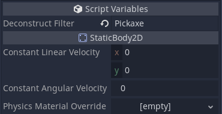

The code we wrote in the previous chapters doesn’t take the amount returned by `_get_pickup_count()` into account, so only one stone will drop.

To produce more, we need to update `EntityPlacer._finish_deconstruct()`.

We update the call to `drop_entity()` by making it in a loop.

Open `EntityPlacer.gd` and move the line that says `_drop_entity(Blueprint.instance(), location)` inside a loop.

```
func _finish_deconstruct(cellv: Vector2) -> void:
    #...
    #if Library.blueprints.has(entity_name):
        #...
        for _i in entity.pickup_count:
            _drop_entity(Blueprint.instance(), location)
    #...
```

Except you’re still doing it with your bare hands.

Hands might be a handy tool, they’re not the right one for this job.

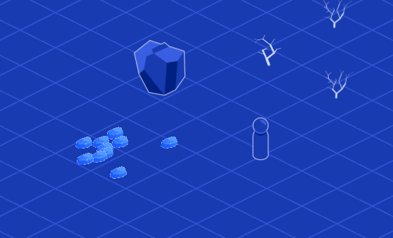

## Requiring the pickaxe to mine boulders

We have a pickaxe, let’s make it so we have to use it.

While we’re in `EntityPlacer.gd`, in `_deconstruct()`, we can check for tools there.

We can change the amount of time it takes while we’re at it if we’re using a crude tool, too.

Be mindful of the commented lines of code below. I included them so you can see where to add the new code.

```
func _deconstruct(event_position: Vector2, cellv: Vector2) -> void:
    # Get the blueprint in the player's hand currently.
    var blueprint: BlueprintEntity = _gui.blueprint
    var blueprint_name := ""

    # If it's a tool, get its custom tool name, otherwise just get its normal
    # name from the library.
    if blueprint and blueprint is ToolEntity:
        blueprint_name = blueprint.tool_name
    elif blueprint:
        blueprint_name = Library.get_entity_name_from(blueprint)

    # Check the entity we're trying to decosntruct.
    var entity := _tracker.get_entity_at(cellv)

    # If it has a deconstruct filter property, and the blueprint we're holding
    # in our hand is part of the filter, then we can proceed. Otherwise, return
    # so we don't deconstruct it.
    if (
        not entity.deconstruct_filter.empty()
        and (not blueprint or not blueprint_name in entity.deconstruct_filter)
    ):
        return

    #_deconstruct_timer.connect(
    #  "timeout", self, "_finish_deconstruct", [cellv], CONNECT_ONESHOT
    #)

    var modifier := 1.0 if not blueprint is ToolEntity else 1.0 / blueprint.tool_speed
    #_deconstruct_timer.start(DECONSTRUCT_TIME * modifier)
    #_current_deconstruct_location = cellv
```

That should make is so you need to select the pickaxe with your mouse before you can deconstruct a boulder.

In the next lesson, we’ll add lumbers and ore boulders, and polish the deconstruction mechanic.

## Code reference

`ToolEntity.gd`

```
class_name ToolEntity
extends BlueprintEntity

export var tool_speed := 1.0

export var tool_name := ""
```

`BoulderEntity.gd`

```
extends Entity

const REGIONS := [
    Rect2(10, 780, 100, 100),
    Rect2(120, 780, 100, 100),
    Rect2(230, 780, 100, 100)
]


func _ready() -> void:
    var index := int(rand_range(0, REGIONS.size() - 1))
    $Sprite.region_rect = REGIONS[index]
    var collision: CollisionPolygon2D = get_child(index + 1)
    collision.disabled = false
    collision.show()

    scale.x = 1 if rand_range(0, 10) < 5 else -1


func get_entity_name() -> String:
    return "Stone"


func _get_pickup_count() -> int:
    return 10
```

`EntityPlacer.gd`’s `_deconstruct()` and `_finish_deconstruct()` functions.

[output not shown]